# Análisis de una serie temporal.

Carlos Blom-Dahl Ramos

# 1 Descripción gráfica de la serie temporal

Vamos a estudiar la serie temporal del paro registrado en la provincia de Albacete entre los años 1977 y 2005, habiéndose tomado una muestra cada mes. Los datos se han obtenido del Instituto Nacional de Estadística (INE).

Cargamos y visualicemos la serie de los datos.

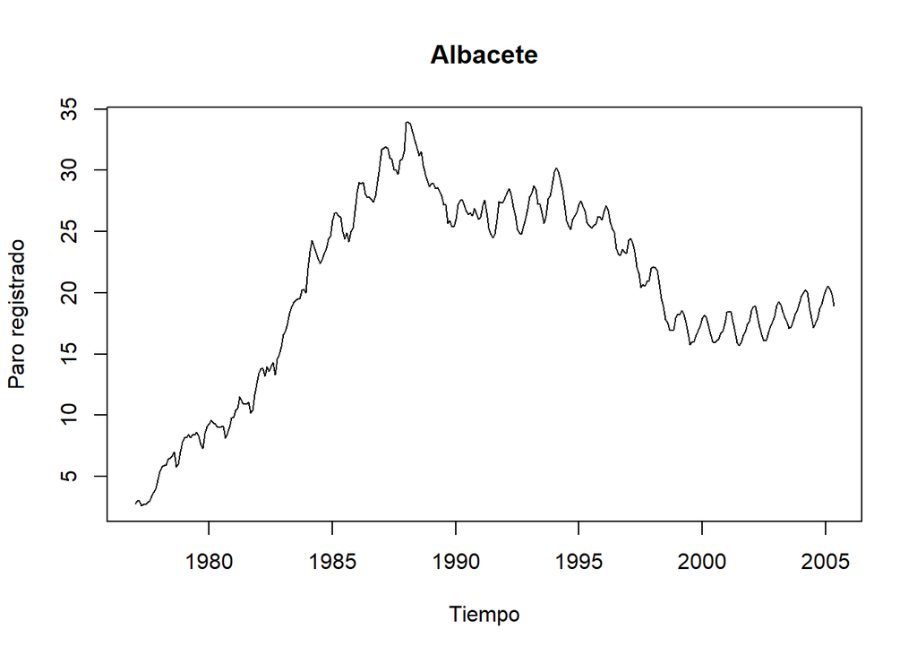

```r
df <- read_excel("SerieBuena.xlsx")
df<-as.data.frame(df)
fechas<-seq(as.Date("1977-01-01"), by="month", length=length(df$SERIES))
df$SERIES <- fechas
rownames(df) <- df[["SERIES"]]
df_ALB<-df[c("SERIES", "PARO REGISTRADO. ALBACETE")]
Serie_ts<-ts(df_ALB$`PARO REGISTRADO. ALBACETE`,start=c(1977,1),end=c(2005,5), frequency=12)

#Visualizamos la serie:

plot(Serie_ts,xlab="Tiempo", ylab="Paro registrado", main="Albacete")
```

A continuación, realizaremos un diagrama de cajas y bigotes agrupando los datos a nivel mensual. Esto nos permite ver la estacionalidad de la serie.

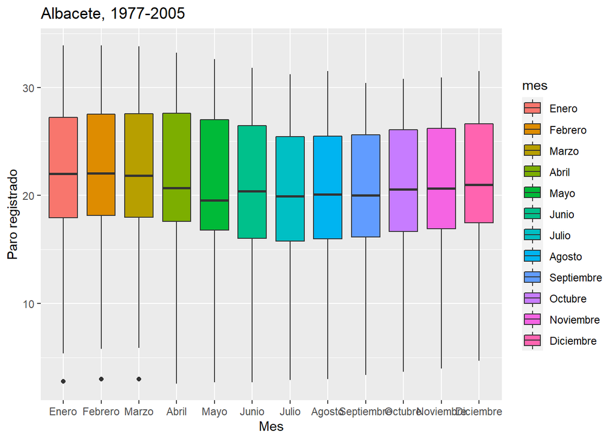

```r
datos.df_ALB <- data.frame(mes= as.numeric(format(df_ALB$SERIES,'%m')), df_ALB)
datos.df_ALB["SERIES"]<-NULL
datos.df_ALB$mes<-factor(datos.df_ALB$mes, levels=1:12, labels=c("Enero","Febrero","Marzo","Abril","Mayo","Junio","Julio","Agosto","Septiembre","Octubre","Noviembre","Diciembre")) #Ordenamos los meses para que los represente por orden temporal.
ggplot(datos.df_ALB,aes(x=mes,y=PARO.REGISTRADO..ALBACETE,fill=mes))+
      geom_boxplot()+ labs(title="Albacete, 1977-2005", x='Mes', y='Paro registrado')
```

A continuación haremos la gráfica estacional, es decir, dispondremos la información de forma anual.

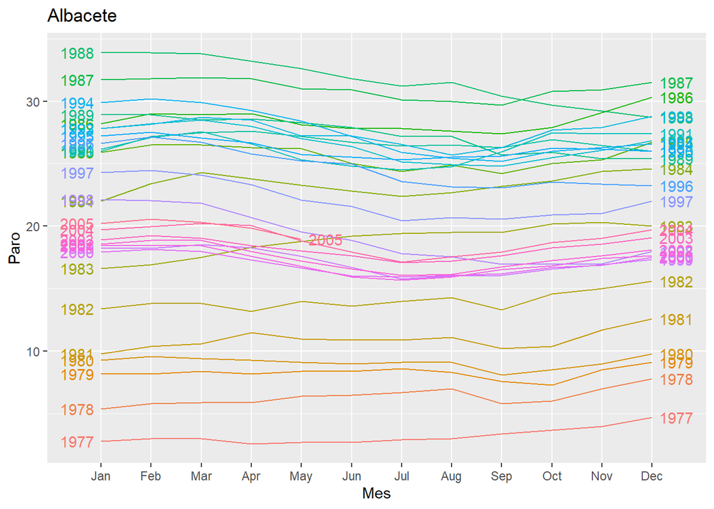

```r
ggseasonplot(Serie_ts, year.labels=TRUE, year.labels.left=TRUE) +
  xlab("Mes")+ylab("Paro") +
  ggtitle("Albacete")
```

Con este gráfico corroboramos el hecho de que existe cierta estacionalidad, ya que vemos como casi todos los años se produce un pico descendente en los meses cercanos al verano.

# 2 Metodología Holt-Winters

## 2.1 Holt-Winters aditivo

```r
insample <- window(Serie_ts,start=c(1977,1),end=c(2004,05))

outsample <- window(Serie_ts,start=c(2004,6),end=c(2005,5))

#Reservamos 2018 para valorar la predicción

fitSerie_ALB<- HoltWinters(insample, seasonal='additive')
fitSerie_ALB$coefficients
```

```
##           a           b          s1          s2          s3          s4
## 19.25190752  0.03271374 -0.90453744 -1.35757359 -1.11315228 -0.76553916
##          s5          s6          s7          s8          s9         s10
## -0.29781470 -0.04956136  0.28749801  0.89178873  1.08332450  1.07484537
##         s11         s12
##  0.44914401 -0.41390752
```

Extraemos los coeficientes $\alpha$, $\beta$ y $\gamma$ del modelo, que son las componentes *level*, tendencial y estacional, respectivamente.

```r
fitSerie_ALB$alpha
```

```
##    alpha
## 0.850112
```

```r
fitSerie_ALB$beta
```

```
##       beta
## 0.03809124
```

```r
fitSerie_ALB$gamma
```

```
## gamma
##     1
```

Visualizamos el ajuste *Holt-Winters* aditivo.

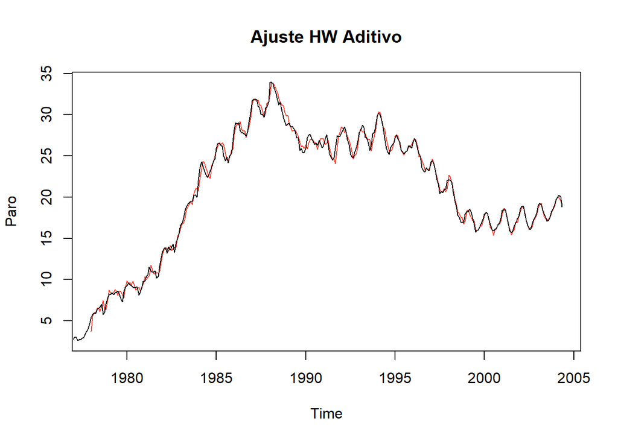

```r
plot(fitSerie_ALB, ylab='Paro', main='Ajuste HW Aditivo')
```

A continuación haremos un estudio de bondad de ajuste para validar el modelo. Para ello, consideraremos el primer año para el cálculo de las condiciones iniciales de nuestro problema.

```r
insamplecut <- window(insample,start=c(1978,1),end=c(2004,05))
# El año 1977 se utiliza para calcular las condiciones iniciales.
# El ajuste pues se obtiene a partir de enero de enero de 1978.
fitval<-fitted(fitSerie_ALB)
rmse <- sqrt(mean((insamplecut-fitval[,1])^2))
mape <- 100*mean(abs(insamplecut-fitval[,1])/insamplecut)
```

Podemos concluir que nuestro ajuste es bueno, ya que obtenemos un RMSE=0.5363817 y un MAPE=2.3029739.

## 2.2 Holt-Winters multiplicativo

```r
fitSerie_ts_mult <- HoltWinters(insample,seasonal="multiplicative")
fitSerie_ts_mult$coefficients
```

```
##            a            b           s1           s2           s3           s4
## 19.980266633 -0.006196292  0.913795984  0.882826724  0.890775903  0.916529039
##           s5           s6           s7           s8           s9          s10
##  0.941094615  0.953088645  0.974847792  1.012422812  1.027608898  1.029752388
##          s11          s12
##  0.999095126  0.942830261
```

Extraemos los coeficientes $\alpha$, $\beta$ y $\gamma$ del modelo, que son las componentes *level*, tendencial y estacional, respectivamente.

```r
fitSerie_ts_mult$alpha
```

```
##     alpha
## 0.5302317
```

```r
fitSerie_ts_mult$beta
```

```
##      beta
## 0.0206979
```

```r
fitSerie_ts_mult$gamma
```

```
## gamma
##     1
```

A continuación, ajustaremos el modelo a nuestros datos y haremos una visualización de los mismos.

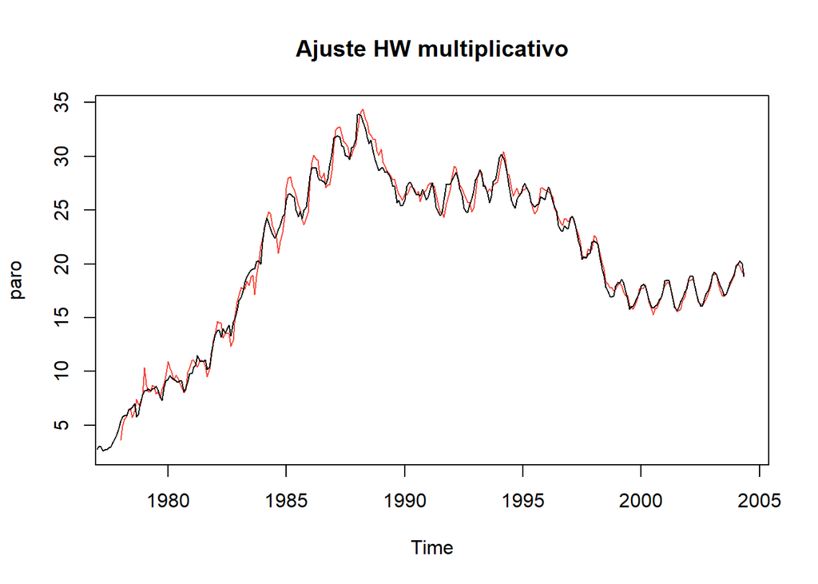

```r
fitval_mult <- fitted(fitSerie_ts_mult)

plot(fitSerie_ts_mult,ylab="paro",main="Ajuste HW multiplicativo")
```

Por último, revisaremos cómo de bueno es nuestro ajuste calculando el *RMSE* y el *MAPE*.

```r
#valoramos la bondad del ajuste
rmse_mult <- sqrt(mean((insamplecut-fitval_mult[,1])^2))
mape_mult <- 100*mean(abs(insamplecut-fitval_mult[,1])/insamplecut)
rmse_mult; mape_mult
```

```
## [1] 0.759285
```

```
## [1] 3.169495
```

## 2.3 Holt-Winters aditivo aplicado a la serie transformada

Con el fin de eliminar la heterocedasticidad, procedemos a realizar una transformación logarítmica a nuestros datos.

```r
loginsample<-log(insample)

fitSerie_ts_log <- HoltWinters(loginsample,seasonal="additive")
fitSerie_ts_log$coefficients
```

```
##            a            b           s1           s2           s3           s4
##  3.025780041  0.002150780 -0.122012191 -0.158357400 -0.151438326 -0.125701123
##           s5           s6           s7           s8           s9          s10
## -0.101780526 -0.089096048 -0.064401657 -0.022737829 -0.005041013 -0.001863541
##          s11          s12
## -0.032436472 -0.089903935
```

Extraemos los coeficientes $\alpha$, $\beta$ y $\gamma$ del modelo, que son las componentes *level*, tendencial y estacional, respectivamente.

```r
fitSerie_ts_log$alpha
```

```
##     alpha
## 0.5731016
```

```r
fitSerie_ts_log$beta
```

```
##       beta
## 0.04573731
```

```r
fitSerie_ts_log$gamma
```

```
## gamma
##     1
```

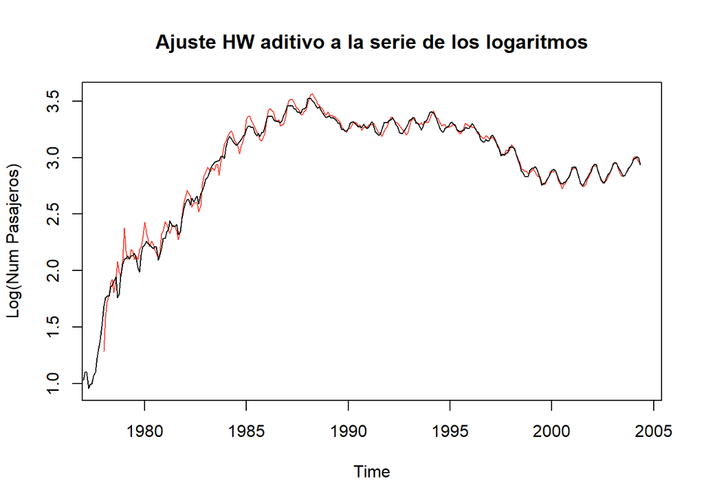

```r
fitval_log <- fitted(fitSerie_ts_log)

plot(fitSerie_ts_log,ylab="Log(Num Pasajeros)",main="Ajuste HW aditivo a la serie de los logaritmos")
```

```r
# Valoramos la bondad del ajuste. Para ello, volvemos previamente a la escala original

fitval_ori <- exp(fitval_log[,1])

rmse_log <- sqrt(mean((insamplecut-fitval_ori)^2))
mape_log <- 100*mean(abs(insamplecut-fitval_ori)/insamplecut)
rmse_log; mape_log
```

```
## [1] 0.8804305
```

```
## [1] 3.621335
```

El método con menor error de ajuste (tanto RMSE como MAPE) es Holt-Winters con estacionalidad aditiva. Este será, por tanto, el método utilizado para calcular la predicción para el año 2005.

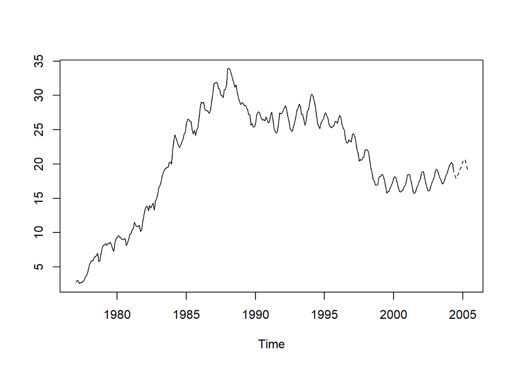

```r
pred <- predict(fitSerie_ALB,12)
# pred contiene las predicciones puntuales para los 12 meses de 2019
ts.plot(insample,pred,lty=1:2)
```

```r
# Valoramos la capacidad predictiva del método

rmse_pred <- sqrt(mean((outsample-pred)^2))
mape_pred <- 100*mean(abs(outsample-pred)/outsample)
rmse_pred;mape_pred
```

```
## [1] 0.449229
```

```
## [1] 2.072972
```

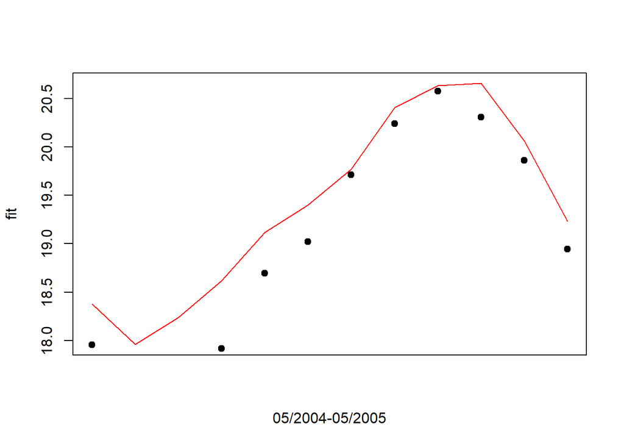

```r
plot(pred, col="red",xaxt="n",xlab="05/2004-05/2005")
points(outsample,pch=19)
```

y calcular el intervalo de predicción al 95%:

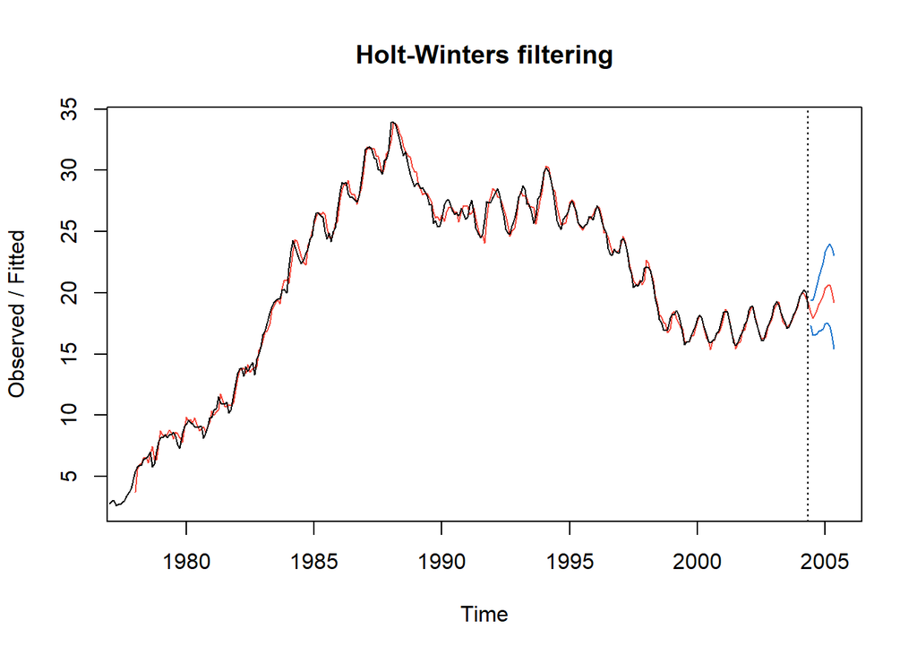

```r
pred <- predict(fitSerie_ALB,n.ahead=12,prediction.interval=TRUE,level=0.95)
plot(fitSerie_ALB, pred)
```

# 3 Análisis de la serie mediante la metodología Box-Jenkins.

Para eliminar la heterocedasticidad asociada a la serie, trabajaremos con una transformación logarítmica de la misma. El primer paso que debemos de realizar el suprimir la estacionalidad de la serie, con el fin de convertirla en estacionaria. Para ello, como los datos se han tomado de forma mensual, calculamos una diferencia con un retraso de 12 ($D=1$).

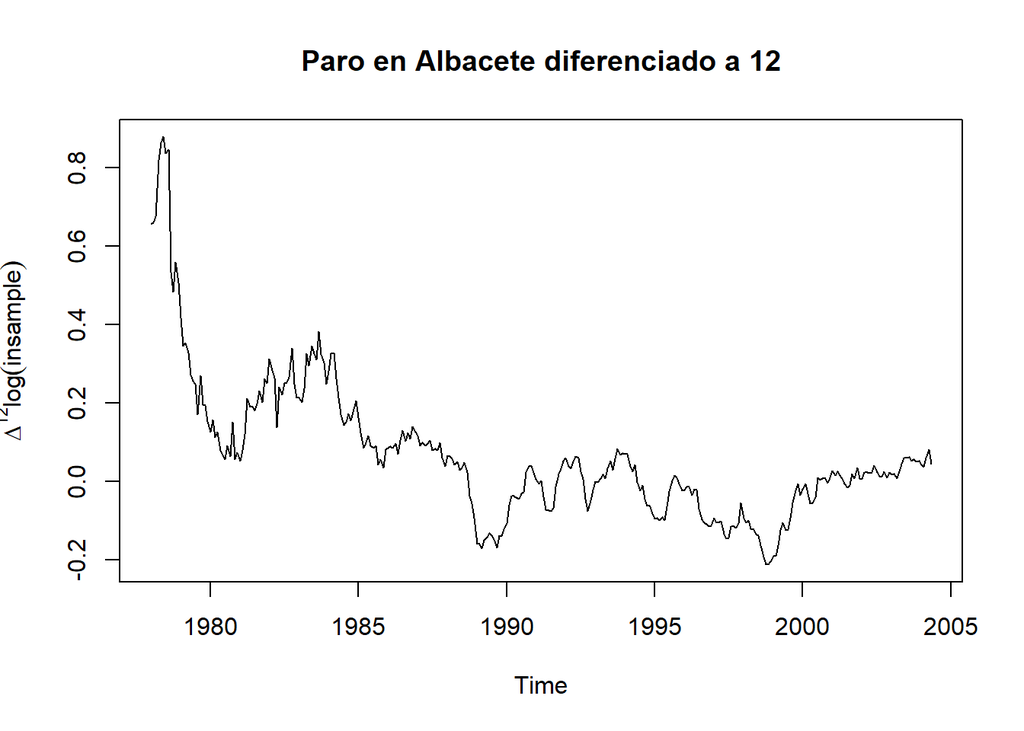

```r
d12loginsample <- diff(loginsample,lag=12, differences=1)
plot(d12loginsample, ylab=expression(Delta^{12}*log(insample)), main="Paro en Albacete diferenciado a 12")
```

A continuación, para lograr la estacionariedad debemos de eliminar la tendencia, por lo que aplicamos una diferencia con un retraso de 1 ($d=1$).

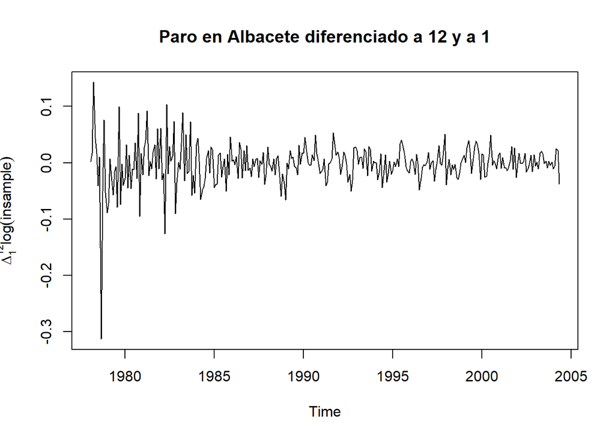

```r
dd12loginsample <- diff(d12loginsample)
plot(dd12loginsample, ylab=expression(Delta[1]^{12}*log(insample)),main="Paro en Albacete diferenciado a 12 y a 1")
```

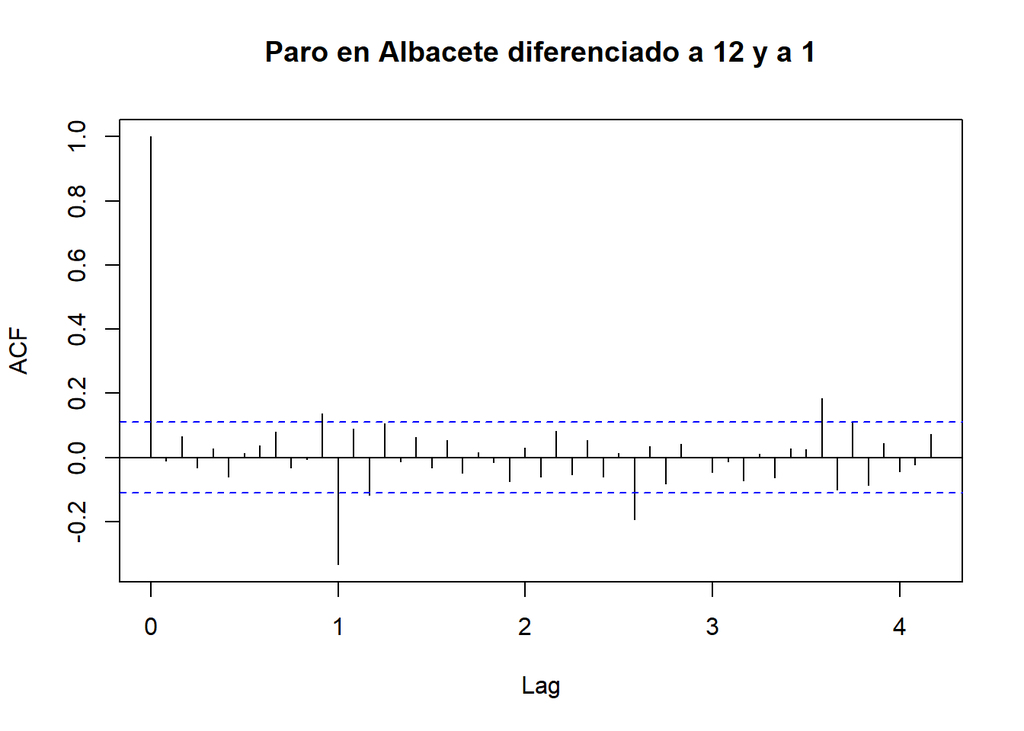

```r
acf(dd12loginsample,lag.max=50, main="Paro en Albacete diferenciado a 12 y a 1")
```

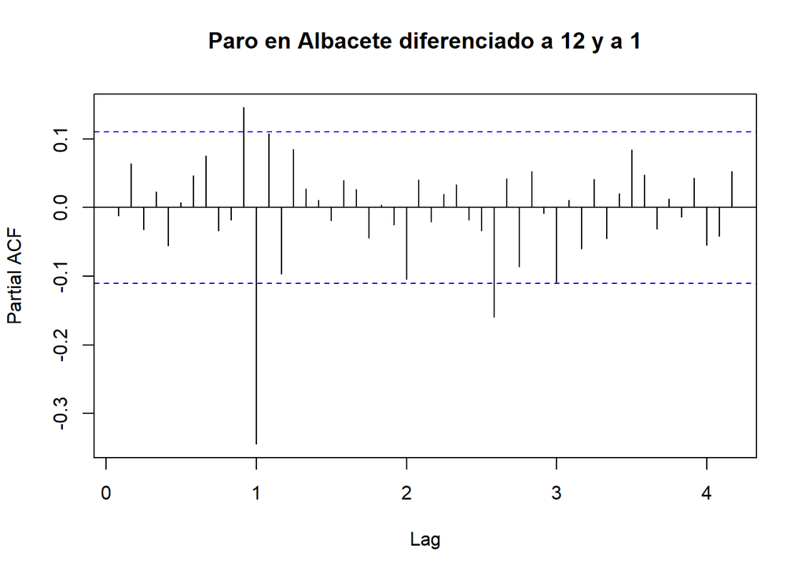

```r
pacf(dd12loginsample,lag.max=50, main="Paro en Albacete diferenciado a 12 y a 1")
```

```r
arima1<-arima(x = loginsample, order = c(1, 1, 0), seasonal = list(order = c(0, 1, 1), period = 12))

arima2<-arima(x = loginsample, order = c(1, 1, 0), seasonal = list(order = c(1, 1, 1), period = 12))

arima3<-auto.arima(loginsample)

arima1_pred<-forecast(arima1, 12)
arima2_pred<-forecast(arima2,12)
arima3_pred<-forecast(arima3,12)
```

A continuación, valoraremos la bondad de ajuste de nuestro modelo, teniendo en cuenta que antes será necesario deshacer la transformación logarítmica hecha anteriormente. Para ello nos valdremos de la función exponencial.

```r
# Valoramos la bondad de ajuste
rmse_pred1 <- sqrt(mean((outsample-exp(as.numeric(arima1_pred$mean)))^2))
mape_pred1 <- 100*mean(abs(outsample-exp(as.numeric(arima1_pred$mean)))/outsample)
rmse_pred1;mape_pred1
```

```
## [1] 0.1985717
```

```
## [1] 0.8618302
```

```r
rmse_pred2 <- sqrt(mean((outsample-exp(as.numeric(arima2_pred$mean)))^2))
mape_pred2 <- 100*mean(abs(outsample-exp(as.numeric(arima2_pred$mean)))/outsample)
rmse_pred2;mape_pred2
```

```
## [1] 0.199848
```

```
## [1] 0.8689921
```

```r
rmse_pred3 <- sqrt(mean((outsample-exp(as.numeric(arima3_pred$mean)))^2))
mape_pred3 <- 100*mean(abs(outsample-exp(as.numeric(arima3_pred$mean)))/outsample)
rmse_pred3;mape_pred3
```

```
## [1] 0.2052235
```

```
## [1] 0.9121206
```

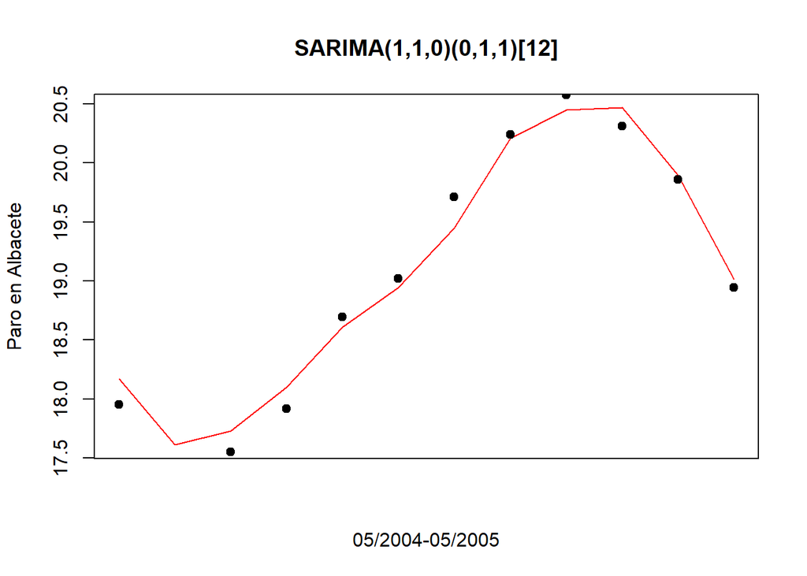

```r
plot(exp(arima1_pred$mean), col="red",xaxt="n",xlab="05/2004-05/2005", ylab="Paro en Albacete", main="SARIMA(1,1,0)(0,1,1)[12]")
points(outsample,pch=19)
```

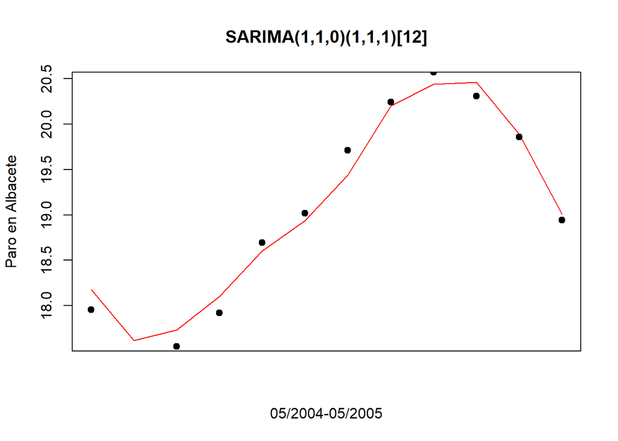

```r
plot(exp(arima2_pred$mean), col="red",xaxt="n",xlab="05/2004-05/2005",ylab="Paro en Albacete",main="SARIMA(1,1,0)(1,1,1)[12]")
points(outsample,pch=19)
```

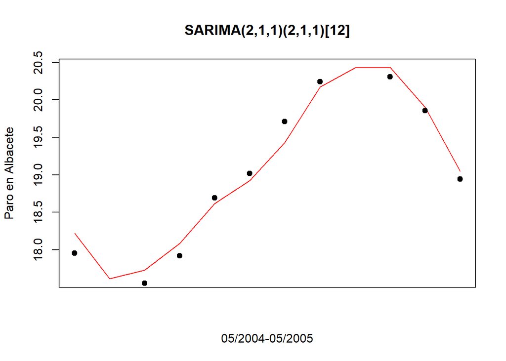

```r
plot(exp(arima3_pred$mean), col="red",xaxt="n",xlab="05/2004-05/2005",ylab="Paro en Albacete",main="SARIMA(2,1,1)(2,1,1)[12]")
points(outsample,pch=19)
```

Como podemos observar, el modelo que mejores predicciones nos ha proporcionado ha sido el *SARIMA(1,1,0)(0,1,1)[12]*.

Revisamos que los residuos de este modelo sean ruido blanco.

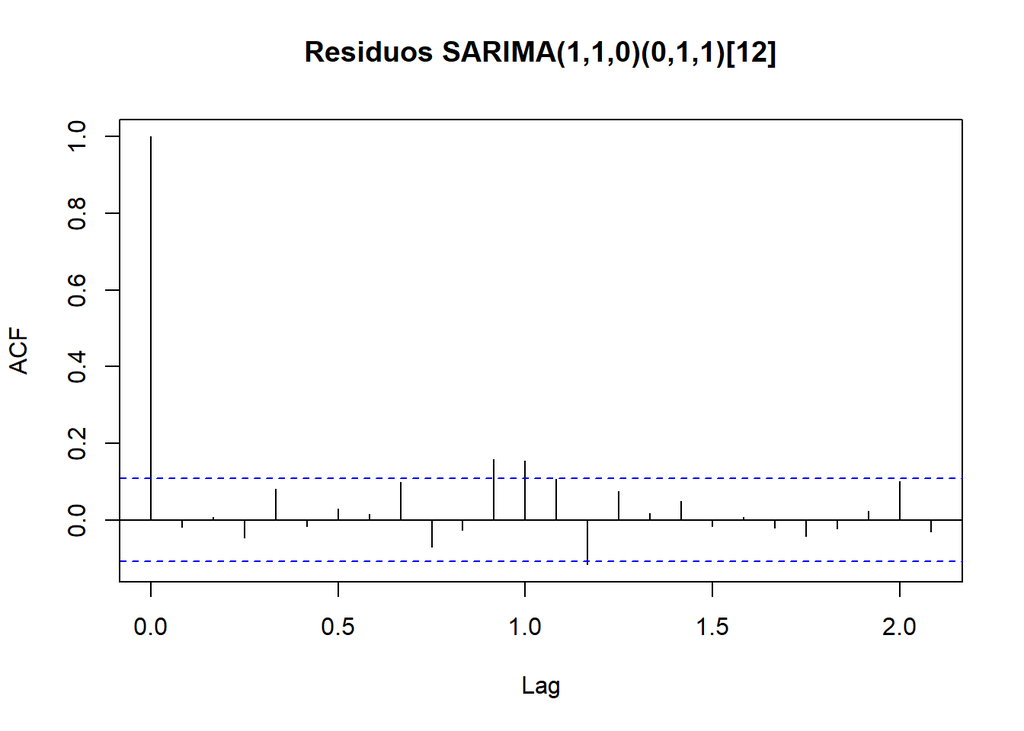

```r
acf(arima1$residuals,main="Residuos SARIMA(1,1,0)(0,1,1)[12]")
```

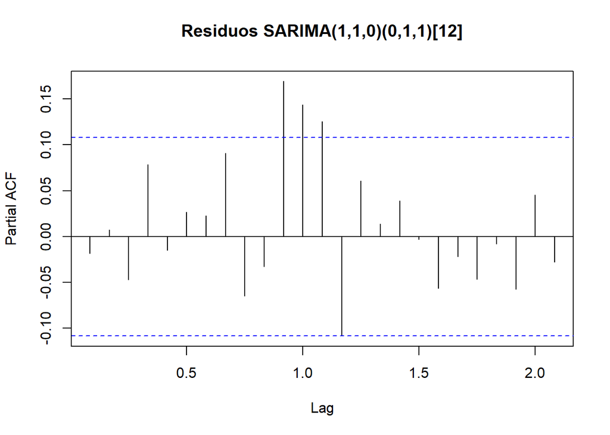

```r
pacf(arima1$residuals, main="Residuos SARIMA(1,1,0)(0,1,1)[12]")
```

Revisaremos a continuación una gráfica de los mismos para poder determinar que son estacionarios.

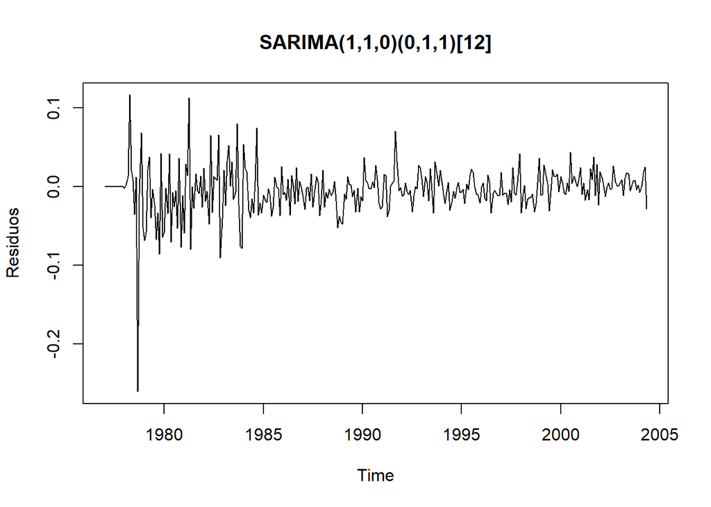

```r
plot(arima1$residuals, ylab="Residuos", main="SARIMA(1,1,0)(0,1,1)[12]")
```

Por último, comprobaremos que se distribuyen de forma normal visualizando su histograma.

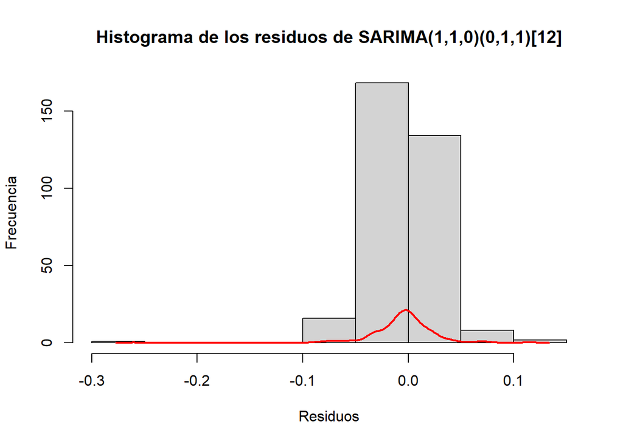

```r
hist(arima1$residuals, main = "Histograma de los residuos de SARIMA(1,1,0)(0,1,1)[12]", ylab="Frecuencia", xlab="Residuos")
lines(density(arima1$residuals), lwd = 2, col = 'red')
```